# Data Analysis

Data Carpentry contributors

## Learning Objectives

> - Build an understanding of the concepts of a `data.frame`
> - Learn to load external data (CSV files) in memory using (`cytokines.csv`) as an example
> - Explore structure and the content of the data
> - Understand what are factors and how to manipulate them
> - Introduce exploratory plots, statistical analyses

# Cytokine Data

Serum cytokine levels were measured in “control”, “infection_A” and “infection_B” patients.

The dataset is stored as a `csv` file: each row holds information for a single patient, and the columns represent:

| Column | Description |
| --- | --- |
| patient_id | unique id for each patient |
| group | status of the patient |
| IL17F | concentration of IL17F |
| IL17A | concentration of IL17A |
| GMCSF | concentration of GMCSF |
| IL2 | concentration of IL2 |
| CXCL9 | concentration of CXCL9 |
| CXCL10 | concentration of CXCL10 |
| ENA78 | concentration of ENA78 |
| IL4 | concentration of IL4 |

### Create Folders and Set Working Directory

- Create a new folder in documents, called “r_scripts”
- Locate “r_scripts” in RStudio (‘Files’, lower right window)
- Set as working directory `setwd("~/Documents/r_scripts")` or use ‘More’ icon
- Create new folder `dir.create("data")` or use ‘New Folder’ icon

### Load Cytokine Data

Download cytokines data:

```r
download.file("http://files.figshare.com/2443264/cytokines_3groups.csv",
              "data/cytokines_3groups.csv")
```

Load the data:

```r
cytokines <- read.csv('data/cytokines_3groups.csv')
```

Type variable `cytokines` to view, or wrap assignment in parentheses to assign and display at the same time.

```r
(cytokines <- read.csv('data/cytokines_3groups.csv'))
```

Check top (first 6 lines) using the function `head()`:

```r
head(cytokines)
```

```
#>   patient_id       group IL17F IL17A GMCSF IL2 CXCL9 CXCL10 ENA78 IL4
#> 1          1     control    79    10    23 231   342    435   342 392
#> 2          2     control    34    12    43 234   465    324   234 324
#> 3          3     control    56    35    23 235   245    645   345 234
#> 4          4     control    67    22    45 264   455    342   435 235
#> 5          5     control    38    35    56 220   354    356   324 235
#> 6          6 infection_A   399    12   212 245  2340    324    56 304
```

The object `cytokines` is a `data.frame`. A `data.frame` can be created by the functions `read.csv()` or `read.table()`.

### Data Frames

`data.frame` is the *de facto* data structure for most tabular data and what we use for statistics and plotting.

A `data.frame` is a collection of vectors of identical lengths. Each vector represents a column, and each vector can be of a different data type (e.g. characters, integers, factors). The `str()` function is useful to inspect the data types of the columns.

Now, generate final data.frame with Log2 transformed cytokine concentrations:

```r
cytokines_L <- data.frame(cytokines[,c(1:2)], log2(cytokines[,-c(1,2)]))
```

Examine the structure of this final `data.frame`:

```r
str(cytokines_L)  # reports the data types for each column
```

$ allow you to select columns using their names:

```r
cytokines_L$IL17F
cytokines_L$group
```

`cytokines_L$group` is a `factor` with 3 levels: “control”, “infection_A”, “infection_B”

### Factors

Factors are used to represent categorical data, and are an important class for statistical analysis and for plotting.

Factors contain a pre-defined set values, known as *levels*.

By default, R always sorts *levels* in alphabetical order. It will assign `1` to the first level, `2` to the next, and so on.

### Visualising and Analysing Cytokine Data

To begin, let’s `plot` our cytokine data:

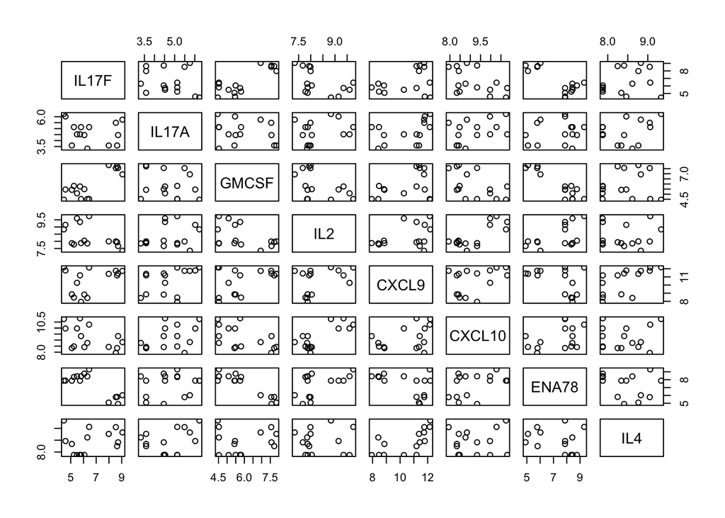

```r
plot(cytokines_L[,-c(1,2)])
```

Add colors to distinguish the 3 groups:

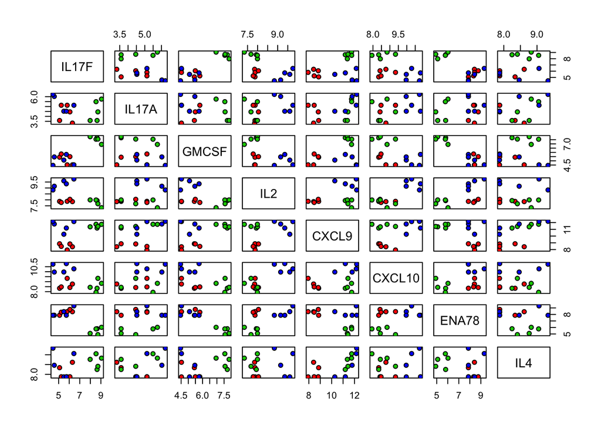

```r
plot(cytokines_L[,-c(1,2)],
     pch = 21,
     bg = c("red", "green3", "blue")[unclass(cytokines_L$group)])
```

Focus in on 3 cytokines that look promising (“IL17F”, “IL2”, and “CXCL9”): To begin, let’s `plot` our cytokine data:

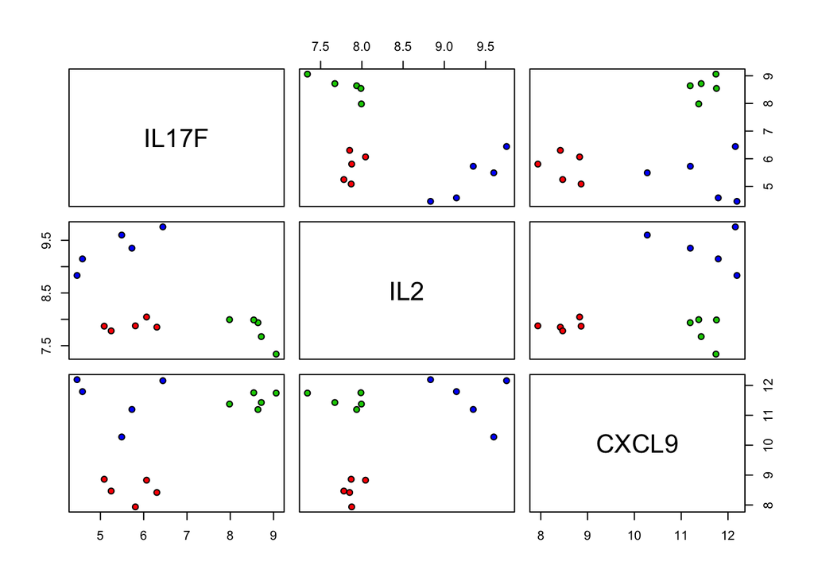

```r
plot(cytokines_L[,c("IL17F","IL2","CXCL9")],
     pch = 21,
     bg = c("red", "green3", "blue")[unclass(cytokines_L$group)])
```

Perform ANOVA:

```r
fit = aov(cytokines_L[,"IL17F"] ~ cytokines_L$group)

summary.aov(fit)
```

Box and Whisker Plot:

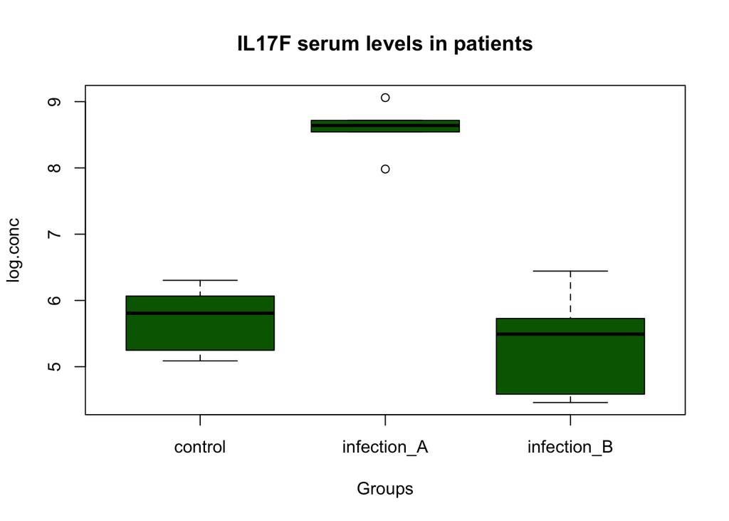

```r
boxplot(cytokines_L$IL17F~cytokines_L$group,
        ylab = "log.conc",
        xlab = "Groups",
        main = "IL17F serum levels in patients",
        col = "dark green")
```

Optional extra, create overlay:

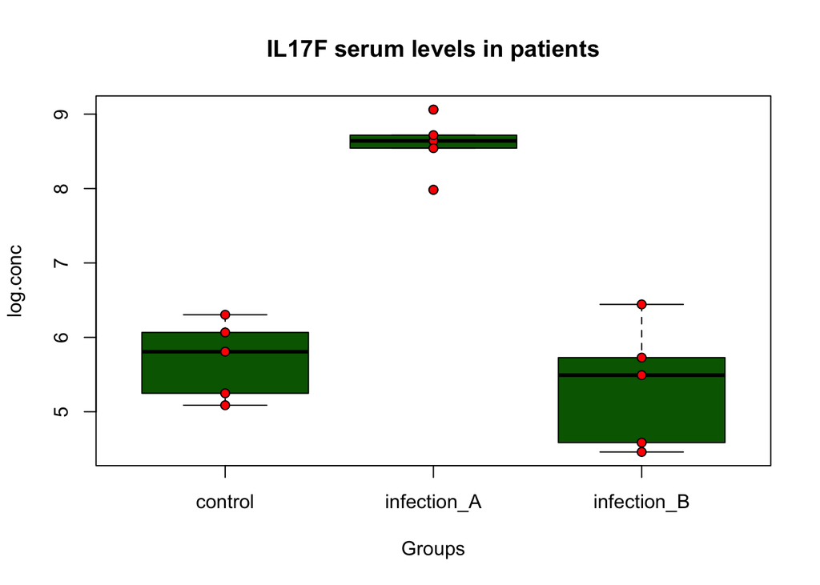

```r
boxplot(cytokines_L$IL17F~cytokines_L$group,
        ylab = "log.conc",
        xlab = "Groups",
        main = "IL17F serum levels in patients",
        col = "dark green")
points(cytokines_L$IL17F~cytokines_L$group,
         pch = 21,
         bg = "red")
```